# Variational Bayesian Shirnkage

Sara Wade

## Data

The data for comes from the Elements of Statistical Learning textbook; and is originally from a study by Stamey et al. (1989) in which they examined the relationship between the level of prostate-specific antigen (psa) and a number of clinical measures in men who were about to receive a prostatectomy. The variables are as follows:

- lpsa - log of the level of prostate-specific antigen
- lcavol - log cancer volume
- lweight - log prostate weight
- age - patient age
- lbph - log of the amount of benign prostatic hyperplasia
- svi - seminal vesicle invasion
- lcp - log of capsular penetration
- gleason - Gleason score
- pgg45 - percent of Gleason scores 4 or 5
- train - test / train split used in ESL

These data are available in `prostate.csv`. Let’s start by reading in the data and some basic EDA.

```r
prostate = read.csv(".././data/prostate.csv")
head(prostate)
```

```
##       lcavol  lweight age      lbph svi       lcp gleason pgg45       lpsa
## 1 -0.5798185 2.769459  50 -1.386294   0 -1.386294       6     0 -0.4307829
## 2 -0.9942523 3.319626  58 -1.386294   0 -1.386294       6     0 -0.1625189
## 3 -0.5108256 2.691243  74 -1.386294   0 -1.386294       7    20 -0.1625189
## 4 -1.2039728 3.282789  58 -1.386294   0 -1.386294       6     0 -0.1625189
## 5  0.7514161 3.432373  62 -1.386294   0 -1.386294       6     0  0.3715636
## 6 -1.0498221 3.228826  50 -1.386294   0 -1.386294       6     0  0.7654678
##   train
## 1  TRUE
## 2  TRUE
## 3  TRUE
## 4  TRUE
## 5  TRUE
## 6  TRUE
```

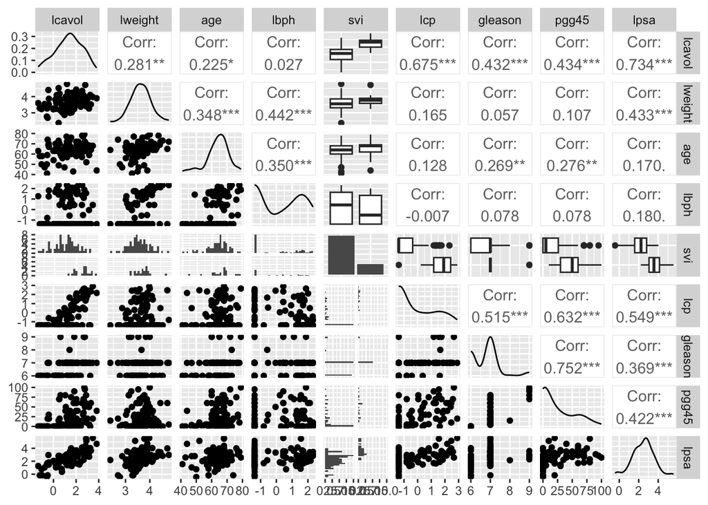

```r
# Visualize the data (except the last column indicating the test/train split)
prostate_gg = prostate
prostate_gg$svi = as.factor(prostate_gg$svi)
ggpairs(prostate_gg, columns = 1:(ncol(prostate)-1))
```

### Split the data

```r
# Split the data
train_df = data.frame(prostate[prostate$train==1,])
train_df = select(train_df, !c(train))
test_df = data.frame(prostate[prostate$train==0,])
test_df = select(test_df, !c(train))


N = dim(train_df)[1] #number of data points
D = dim(train_df) [2] -1 #number of features
Nnew = dim(test_df)[1]
print(paste("Number of data points =",N, " and number of features =", D))
```

```
## [1] "Number of data points = 67  and number of features = 8"
```

### Fit linear regression

Let’s start by fitting a baseline linear regression model.

First, we will scale the inputs.

```r
# Scale the data
train.m = apply(train_df, 2, mean)
train.s = apply(train_df,2,sd)
train_df = (train_df - matrix(train.m,N,D+1,byrow = TRUE))/matrix(train.s,N,D+1,byrow = TRUE)
test_df = (test_df - matrix(train.m,Nnew,D+1,byrow = TRUE))/matrix(train.s,Nnew,D+1,byrow = TRUE)
```

Fit the linear regression model and visualize the coefficients.

```r
# Fit lm
lm_prostate = lm(lpsa~., data=train_df)
summary(lm_prostate)
```

```
##
## Call:
## lm(formula = lpsa ~ ., data = train_df)
##
## Residuals:
##      Min       1Q   Median       3Q      Max
## -1.36503 -0.28272 -0.04491  0.37209  1.23095
##
## Coefficients:
##               Estimate Std. Error t value Pr(>|t|)
## (Intercept) -5.200e-16  7.205e-02   0.000  1.00000
## lcavol       5.931e-01  1.105e-01   5.366 1.47e-06 ***
## lweight      2.423e-01  8.808e-02   2.751  0.00792 **
## age         -1.180e-01  8.455e-02  -1.396  0.16806
## lbph         1.755e-01  8.538e-02   2.056  0.04431 *
## svi          2.563e-01  1.038e-01   2.469  0.01651 *
## lcp         -2.393e-01  1.282e-01  -1.867  0.06697 .
## gleason     -1.732e-02  1.180e-01  -0.147  0.88389
## pgg45        2.296e-01  1.321e-01   1.738  0.08755 .
## ---
## Signif. codes:  0 '***' 0.001 '**' 0.01 '*' 0.05 '.' 0.1 ' ' 1
##
## Residual standard error: 0.5897 on 58 degrees of freedom
## Multiple R-squared:  0.6944, Adjusted R-squared:  0.6522
## F-statistic: 16.47 on 8 and 58 DF,  p-value: 2.042e-12
```

```r
tidy_reg_conf_int = tidy(lm_prostate,conf.int =TRUE)
```

Compute the RMSE on the test data

```r
yhat = predict(lm_prostate, test_df)
rmse_lm = sqrt(mean((yhat-test_df$lpsa)^2))
print(paste("The RMSE for the linear model is ",rmse_lm))
```

```
## [1] "The RMSE for the linear model is  0.597769431021197"
```

## Lasso

Now, we will use `glmnet` to fit a lasso model. First, we need to use cross-validation to tune $\lambda$.

```r
set.seed (1)
X = as.matrix(train_df[,1:D])
y = train_df$lpsa
cv.out=cv.glmnet(X, y, alpha=1, standardize = FALSE)
bestlam=cv.out$lambda.min
print(bestlam)
```

```
## [1] 0.006281436
```

Now, let’s refit with the best lambda

```r
glmnet.out=glmnet(X, y, alpha=1, lambda = bestlam, standardize = FALSE)
glmnet.out$beta
```

```
## 8 x 1 sparse Matrix of class "dgCMatrix"
##                 s0
## lcavol   0.5728689
## lweight  0.2390965
## age     -0.1050754
## lbph     0.1683333
## svi      0.2434682
## lcp     -0.1981421
## gleason  .
## pgg45    0.1953291
```

```r
tidy_reg_conf_int$lasso = as.matrix(predict(glmnet.out,type="coefficients",s=bestlam))
```

Compute the RMSE on the test data

```r
Xtest = as.matrix(test_df[,1:D])
yhat = predict(glmnet.out, s = bestlam, Xtest)
rmse_lasso = sqrt(mean((yhat-test_df$lpsa)^2))
print(paste("The RMSE for the lasso is ",rmse_lasso))
```

```
## [1] "The RMSE for the lasso is  0.587015428770515"
```

## Bayesian Lasso

Run a simple Gibbs sampling algorithm.

```r
source(".././R/gibbs_blasso.R")

# Define prior parameters
priors = list(s=1, a_sigma = 2, b_sigma = 1, s2_0 = 10)

I = 2000 #number of iterations

# Initialize
w_init = lm_prostate$coefficients
sigma_init = mean(lm_prostate$residuals^2)

#Run MCMC
blasso_out = gibbs_blasso(X,y, priors, I , w_init, sigma_init)
```

```
## [1] "Number of iterations completed: 100"
## [1] "Number of iterations completed: 200"
## [1] "Number of iterations completed: 300"
## [1] "Number of iterations completed: 400"
## [1] "Number of iterations completed: 500"
## [1] "Number of iterations completed: 600"
## [1] "Number of iterations completed: 700"
## [1] "Number of iterations completed: 800"
## [1] "Number of iterations completed: 900"
## [1] "Number of iterations completed: 1000"
## [1] "Number of iterations completed: 1100"
## [1] "Number of iterations completed: 1200"
## [1] "Number of iterations completed: 1300"
## [1] "Number of iterations completed: 1400"
## [1] "Number of iterations completed: 1500"
## [1] "Number of iterations completed: 1600"
## [1] "Number of iterations completed: 1700"
## [1] "Number of iterations completed: 1800"
## [1] "Number of iterations completed: 1900"
## [1] "Number of iterations completed: 2000"
```

Check mixing and determine burnin (note here we started with good initial values!)

```r
# Check convergence using coda

# Remove burnin
b = 1000
blasso_out$w = blasso_out$w[b:I,]
blasso_out$tau = blasso_out$tau[b:I,]
blasso_out$sigma = blasso_out$sigma[b:I]
```

Let’s compare the coefficents

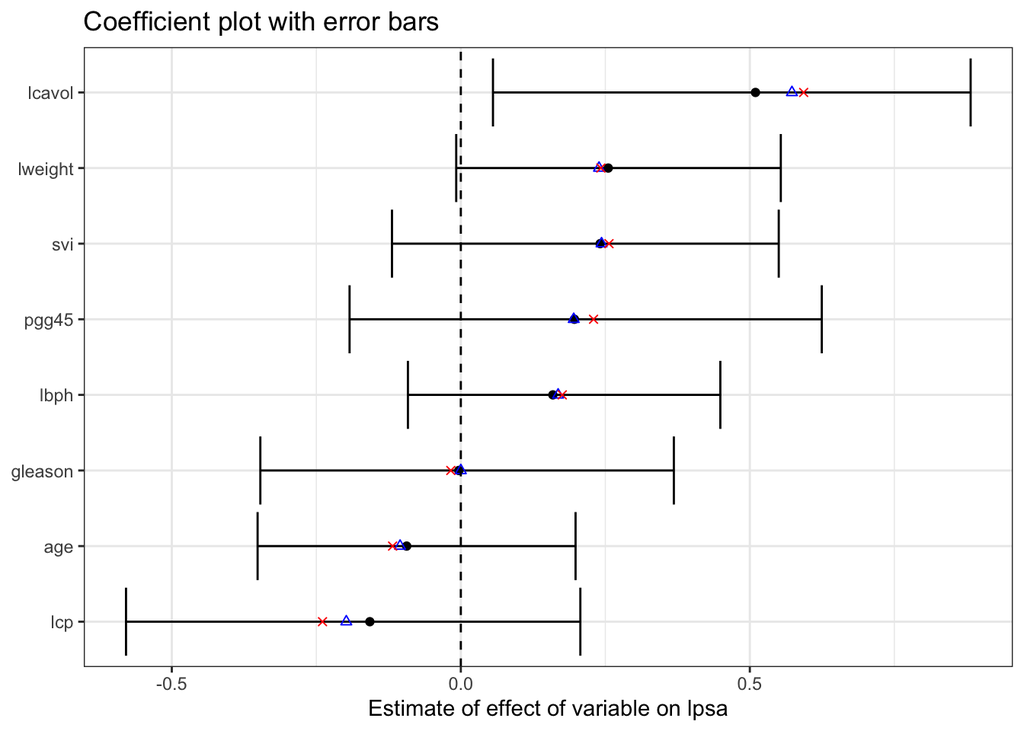

```r
# Compute posterior mean and HPD intervals
bl_what = apply(blasso_out$w,2,mean)
bl_wci = apply(blasso_out$w,2,function(x){HPDinterval(as.mcmc(x))})

tidy_reg_conf_int$ls = tidy_reg_conf_int$estimate
tidy_reg_conf_int$estimate = bl_what
tidy_reg_conf_int$conf.low = bl_wci[1,]
tidy_reg_conf_int$conf.high = bl_wci[2,]

tidy_reg_conf_int %>%
  filter(term != "(Intercept)") %>%
  # reorder the coefficients so that the largest is at the top of the plot
  mutate(term = fct_reorder(term, estimate)) %>%
  ggplot(aes(estimate, term)) +
  geom_point() +
  geom_errorbarh(aes(xmin = conf.low, xmax = conf.high)) +
  # add lasso estimates
  geom_point(aes(lasso, term),shape = 2, color = 'blue') +
  geom_point(aes(ls, term),shape = 4, color = 'red') +
  # add in a dotted line at zero
  geom_vline(xintercept = 0, lty = 2) +
  labs(
    x = "Estimate of effect of variable on lpsa",
    y = NULL,
    title = "Coefficient plot with error bars") +
  theme_bw()
```

Compute the RMSE:

```r
yhat = cbind(rep(1,Nnew),Xtest)%*%bl_what
rmse_blasso = sqrt(mean((yhat-test_df$lpsa)^2))
print(paste("The RMSE for the bayesian lasso is ",rmse_blasso))
```

```
## [1] "The RMSE for the bayesian lasso is  0.588250333489908"
```

## Variational Bayes Lasso

Run a simple VB algorithm

```r
# Define prior parameters
priors = list(s=1, a_sigma = 2, b_sigma = 1, s2_0 = 10)

# Define initialization
init = list(mu_w = lm_prostate$coefficients, Sigma_w = diag(1,D+1),
            a_sigma = priors$a_sigma, b_sigma = priors$b_sigma, mu_tau = rep(2*priors$s^2,D))

I = 100 #number of iterations
thresh = 0.001 # threshold for change in elbo

#Run MCMC
vblasso_out = vblasso(X,y, priors, I, thresh, init)
```

Plot the ELBO

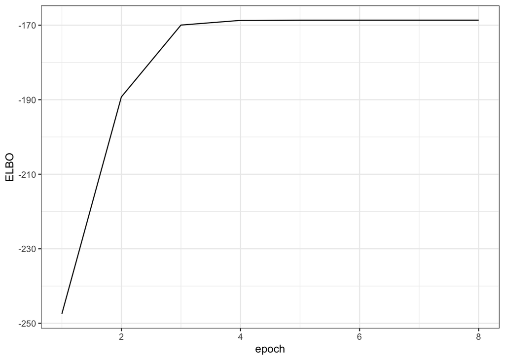

```r
ggplot() +
  geom_line(aes(x = c(1:length(vblasso_out$elbo)), y = vblasso_out$elbo)) +
  theme_bw() +
  labs( x ="epoch", y = "ELBO")
```

Let’s compare the coefficents. The means are very similar but the CIs are smaller (underestimation of the variance).

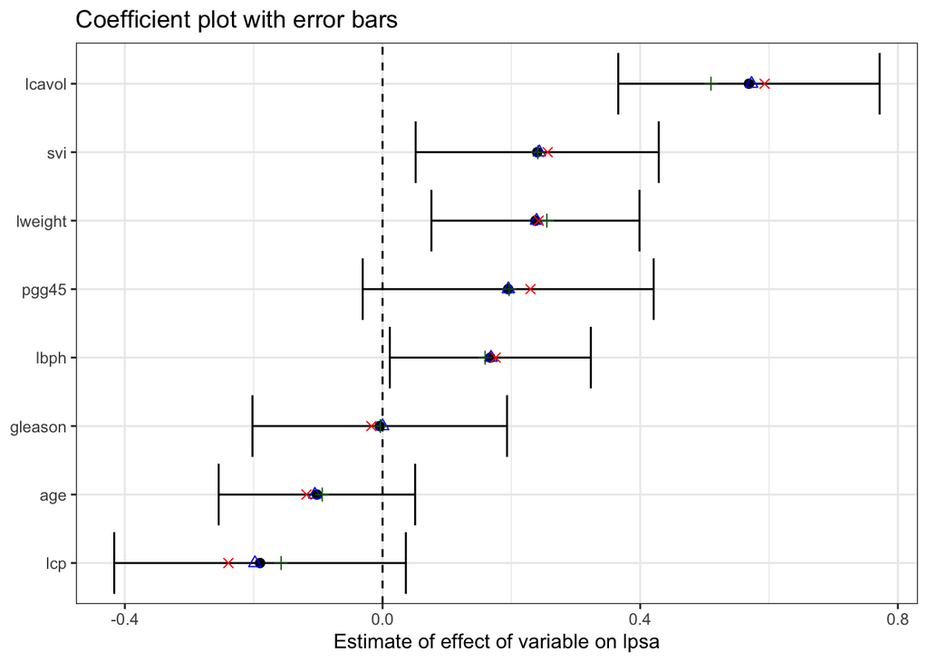

```r
tidy_reg_conf_int$blasso = bl_what
tidy_reg_conf_int$estimate = vblasso_out$mu_w
tidy_reg_conf_int$conf.low = vblasso_out$mu_w+1.96*sqrt(diag(vblasso_out$Sigma_w))
tidy_reg_conf_int$conf.high = vblasso_out$mu_w-1.96*sqrt(diag(vblasso_out$Sigma_w))

tidy_reg_conf_int %>%
  filter(term != "(Intercept)") %>%
  # reorder the coefficients so that the largest is at the top of the plot
  mutate(term = fct_reorder(term, estimate)) %>%
  ggplot(aes(estimate, term)) +
  geom_point(size = 2) +
  geom_errorbarh(aes(xmin = conf.low, xmax = conf.high)) +
  # add lasso estimates
  geom_point(aes(lasso, term),shape = 2, color = 'blue', size = 2) +
  geom_point(aes(blasso, term),shape = 3, color = 'darkgreen',size = 2) +
  geom_point(aes(ls, term),shape = 4, color = 'red',size = 2) +
  # add in a dotted line at zero
  geom_vline(xintercept = 0, lty = 2) +
  labs(
    x = "Estimate of effect of variable on lpsa",
    y = NULL,
    title = "Coefficient plot with error bars") +
  theme_bw()
```

For two correlated variables, let’s compare the gibbs samples of the coefficients with the VB posterior

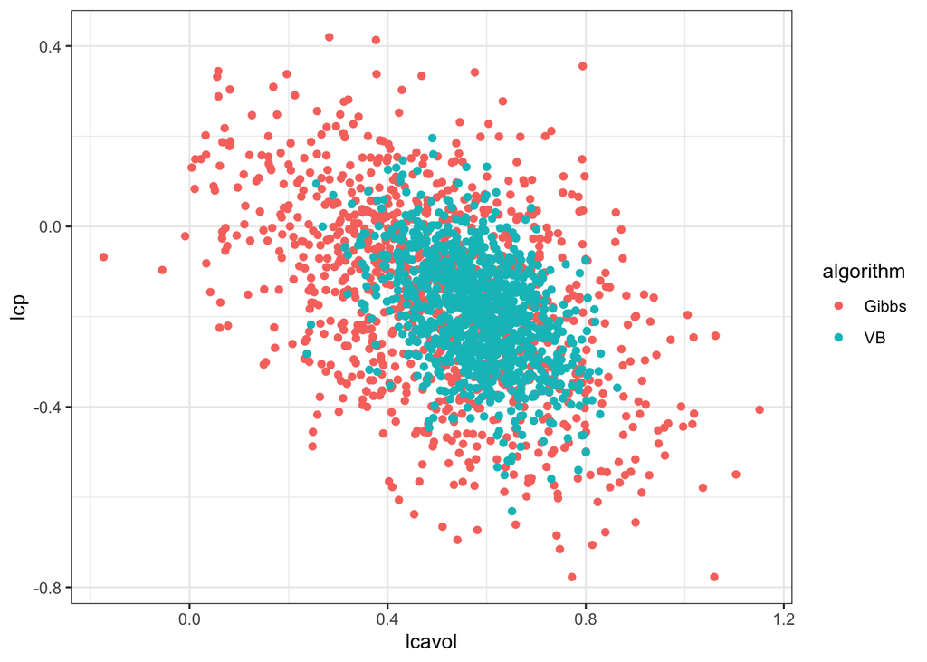

```r
# Compare scatter plot of samples from the two mcmc algorithms
coeff_names = names(train_df)[1:D]
ind1 = 1
ind2 = 6
vblasso_w = rmvnorm(dim(blasso_out$w)[1], vblasso_out$mu_w, vblasso_out$Sigma_w)
df = data.frame(w1 = c(blasso_out$w[,ind1 +1], vblasso_w[,ind1 +1]), w2 = c(blasso_out$w[,ind2 +1], vblasso_w[,ind2 +1]),
                algorithm = c(rep("Gibbs", dim(blasso_out$w)[1]), rep("VB", dim(vblasso_w)[1])))
ggplot(df) +
  geom_point(aes(x = w1, y =w2, color = algorithm)) +
  theme_bw() +
  labs(x=coeff_names[ind1],y=coeff_names[ind2])
```

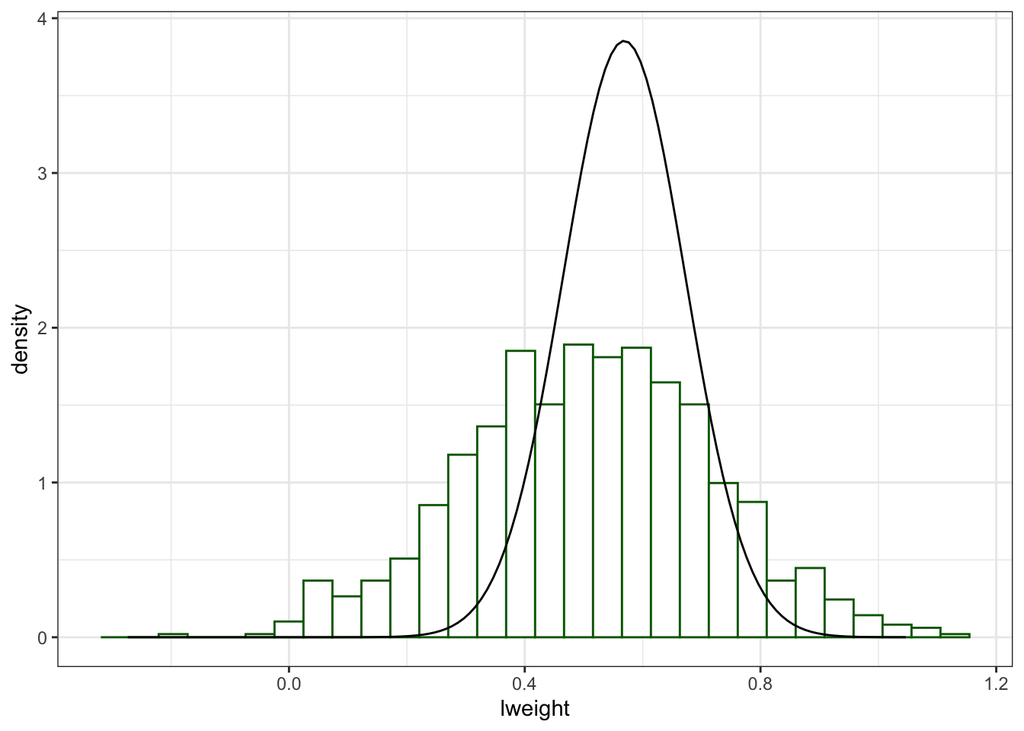

```r
#Compare histogram of gibbs samples with the VB posterior
ind = 2
xseq = seq(min(blasso_out$w[,ind])-.1,max(blasso_out$w[,ind])-.1,0.01)
ggplot() +
  geom_histogram(aes(x = blasso_out$w[,ind], y = ..density..), colour = "darkgreen", fill = "white") +
  geom_line( aes( x = xseq, y = dnorm(xseq, mean = vblasso_out$mu_w[ind],sd = sqrt(vblasso_out$Sigma_w[ind,ind]))), colour = 1) +
  theme_bw() +
  labs(x =coeff_names[ind])
```

Compute the RMSE:

```r
yhat = cbind(rep(1,Nnew),Xtest)%*%vblasso_out$mu_w
rmse_vblasso = sqrt(mean((yhat-test_df$lpsa)^2))
print(paste("The RMSE for the bayesian lasso is ",rmse_vblasso))
```

```
## [1] "The RMSE for the bayesian lasso is  0.586326709280655"
```

## Exercises

1. Try changing s and seeing how it affects the results.
2. Try changing the intialization to a random draw from the prior. How does this affect?
3. Compare the VB posterior with the Gibbs samples for other parameters. What do you notice?
4. Try adding a step to estimate $s$.
5. Suppose $N$ is relatively large. What can be done to help reduce the computational complexity?

## CmdStanR

We will be using CmdStan R, which allows us to to fit the model with automatic differentian variational inference (ADVI): https://arxiv.org/abs/1506.03431. Note, it also allows other inference schemes (mcmc, MAP, laplace).

To install and get started with CmdStanR, see https://mc-stan.org/cmdstanr/articles/cmdstanr.html

For an example with variational inference, see https://mc-stan.org/cmdstanr/reference/model-method-variational.html.

For details and examples on bayesian sparse regression in Rstan, see https://betanalpha.github.io/assets/case_studies/bayes_sparse_regression.html

```r
library(cmdstanr)
mod <- cmdstan_model(".././R/blasso.stan")
mod$print()
```

```
## data {
##   int<lower=1> N; // Number of data
##   int<lower=1> D; // Number of covariates
##   matrix[D, N] X;
##   vector[N] y;
## }
##
## parameters {
##   vector[D] w;
##   real w0;
##   real<lower=0> sigma2;
## }
##
## model {
##   // Strongly regularizing priors
##   w ~ double_exponential(0, 1);
##   w0 ~ normal(0, 10);
##   sigma2 ~ inv_gamma(2, 1);
##
##   y ~ normal(X' * w + w0, sqrt(sigma2));
## }
```

Note that: the variational approximation assumes a Gaussian variational posterior in the unconstrained variable space. Stan implements two ADVI algorithms: the `algorithm="meanfield"` option uses a fully factorized Gaussian for the approximation; the `algorithm="fullrank"` option uses a Gaussian with a full-rank covariance matrix for the approximation.

```r
inputdata <- list(X = t(X), N = N, y = y, D = D)

fit_vb <- mod$variational(data = inputdata, algorithm="fullrank", seed = 123)
```

```
## ------------------------------------------------------------
## EXPERIMENTAL ALGORITHM:
##   This procedure has not been thoroughly tested and may be unstable
##   or buggy. The interface is subject to change.
## ------------------------------------------------------------
## Gradient evaluation took 2.8e-05 seconds
## 1000 transitions using 10 leapfrog steps per transition would take 0.28 seconds.
## Adjust your expectations accordingly!
## Begin eta adaptation.
## Iteration:   1 / 250 [  0%]  (Adaptation)
## Iteration:  50 / 250 [ 20%]  (Adaptation)
## Iteration: 100 / 250 [ 40%]  (Adaptation)
## Iteration: 150 / 250 [ 60%]  (Adaptation)
## Iteration: 200 / 250 [ 80%]  (Adaptation)
## Iteration: 250 / 250 [100%]  (Adaptation)
## Success! Found best value [eta = 0.1].
## Begin stochastic gradient ascent.
##   iter             ELBO   delta_ELBO_mean   delta_ELBO_med   notes
##    100         -137.136             1.000            1.000
##    200         -107.139             0.640            1.000
##    300          -94.501             0.471            0.280
##    400          -85.906             0.378            0.280
##    500          -83.073             0.310            0.134
##    600          -82.221             0.260            0.134
##    700          -82.122             0.223            0.100
##    800          -81.411             0.196            0.100
##    900          -81.701             0.175            0.034
##   1000          -82.099             0.158            0.034
##   1100          -81.825             0.058            0.010
##   1200          -82.089             0.030            0.009   MEDIAN ELBO CONVERGED
## Drawing a sample of size 1000 from the approximate posterior...
## COMPLETED.
## Finished in  0.1 seconds.
```

```r
fit_sum = fit_vb$summary()
fit_sum
```

```
## # A tibble: 12 × 7
##    variable        mean   median     sd    mad        q5      q95
##    <chr>          <dbl>    <dbl>  <dbl>  <dbl>     <dbl>    <dbl>
##  1 lp__        -73.6    -73.0    3.54   3.06   -80.2     -69.2
##  2 lp_approx__  -4.99    -4.63   2.20   2.10    -8.95     -2.00
##  3 w[1]          0.582    0.578  0.126  0.117    0.376     0.800
##  4 w[2]          0.233    0.235  0.0974 0.0989   0.0758    0.387
##  5 w[3]         -0.108   -0.108  0.106  0.104   -0.275     0.0685
##  6 w[4]          0.164    0.162  0.0997 0.0959  -0.00849   0.321
##  7 w[5]          0.258    0.258  0.103  0.108    0.0895    0.421
##  8 w[6]         -0.209   -0.212  0.143  0.146   -0.437     0.0218
##  9 w[7]         -0.0138  -0.0133 0.123  0.125   -0.209     0.188
## 10 w[8]          0.232    0.235  0.143  0.144   -0.00188   0.481
## 11 w0            0.0172   0.0183 0.0796 0.0775  -0.114     0.147
## 12 sigma2        0.379    0.376  0.0678 0.0693   0.279     0.498
```

Let’s plot the coefficients

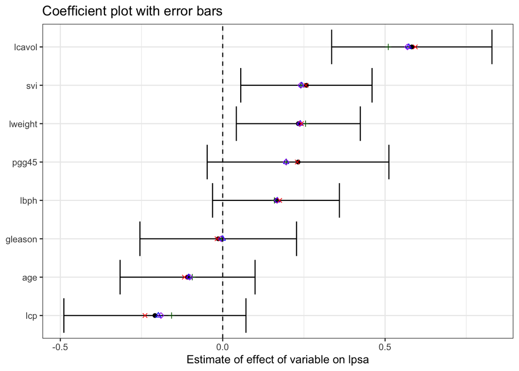

```r
tidy_reg_conf_int$vblasso = vblasso_out$mu_w
tidy_reg_conf_int$estimate = c(fit_sum$mean[D+3], fit_sum$mean[3:(D+2)])
tidy_reg_conf_int$conf.low = c(fit_sum$mean[D+3], fit_sum$mean[3:(D+2)])+1.96*c(fit_sum$sd[D+3], fit_sum$sd[3:(D+2)])
tidy_reg_conf_int$conf.high = c(fit_sum$mean[D+3], fit_sum$mean[3:(D+2)])-1.96*c(fit_sum$sd[D+3], fit_sum$sd[3:(D+2)])

tidy_reg_conf_int %>%
  filter(term != "(Intercept)") %>%
  # reorder the coefficients so that the largest is at the top of the plot
  mutate(term = fct_reorder(term, estimate)) %>%
  ggplot(aes(estimate, term)) +
  geom_point() +
  geom_errorbarh(aes(xmin = conf.low, xmax = conf.high)) +
  # add lasso estimates
  geom_point(aes(lasso, term),shape = 2, color = 'blue') +
  geom_point(aes(blasso, term),shape = 3, color = 'darkgreen') +
  geom_point(aes(vblasso, term),shape = 5, color = 'purple') +
  geom_point(aes(ls, term),shape = 4, color = 'red') +
  # add in a dotted line at zero
  geom_vline(xintercept = 0, lty = 2) +
  labs(
    x = "Estimate of effect of variable on lpsa",
    y = NULL,
    title = "Coefficient plot with error bars") +
  theme_bw()
```

Let’s compare this vb approximation with gibbs and the previous.

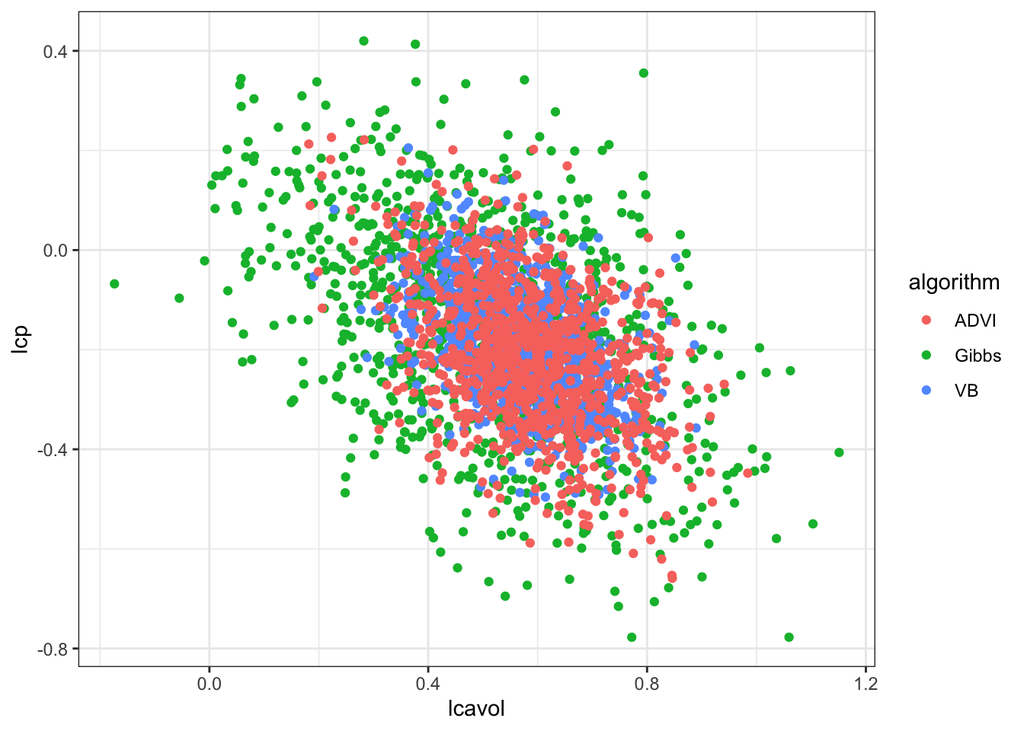

```r
# Compare scatter plot of samples from the two mcmc algorithms
coeff_names = names(train_df)[1:D]
ind1 = 1
ind2 = 6
vblasso_w = rmvnorm(dim(blasso_out$w)[1], vblasso_out$mu_w, vblasso_out$Sigma_w)
vblasso_w2 = fit_vb$draws("w")
df = data.frame(w1 = c(blasso_out$w[,ind1 +1], vblasso_w[,ind1 +1], vblasso_w2[,ind1]),
                w2 = c(blasso_out$w[,ind2 +1], vblasso_w[,ind2 +1], vblasso_w2[,ind2]),
                algorithm = c(rep("Gibbs", dim(blasso_out$w)[1]), rep("VB",dim(vblasso_w)[1]), rep("ADVI", dim(vblasso_w2)[1])))
ggplot(df) +
  geom_point(aes(x = w1, y =w2, color = algorithm)) +
  theme_bw() +
  labs(x=coeff_names[ind1],y=coeff_names[ind2])
```

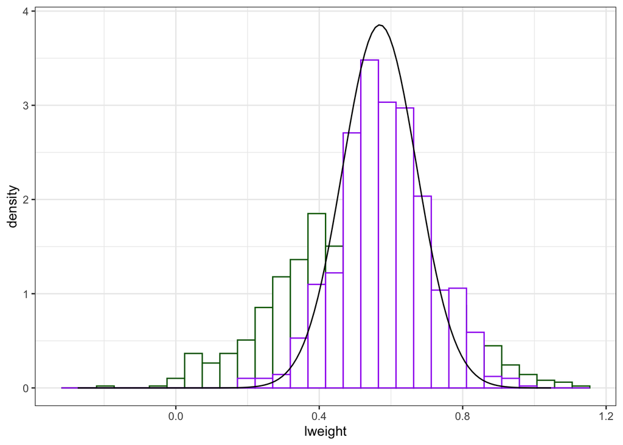

```r
#Compare histogram of gibbs samples with the VB posterior
ind = 2
xseq = seq(min(blasso_out$w[,ind])-.1,max(blasso_out$w[,ind])-.1,0.01)
ggplot() +
  geom_histogram(aes(x = blasso_out$w[,ind], y = ..density..), colour = "darkgreen", fill = "white") +
  geom_histogram(aes(x = vblasso_w2[,ind-1], y = ..density..), colour = "purple", fill = "white") +
  geom_line( aes( x = xseq, y = dnorm(xseq, mean = vblasso_out$mu_w[ind],sd = sqrt(vblasso_out$Sigma_w[ind,ind]))), colour = 1) +
  theme_bw() +
  labs(x =coeff_names[ind])
```

## Exercises

1. Try changing `algorithm="meanfield"` and seeing how it affects the results.
2. Compare the two variational approximations and the gibbs samples for other parameters. What do you notice?